# Assignment 6：運用 AI 爬取農產品交易行情

**專題名稱：**台灣水果價格在 2024 年以來的波動情形：以台北第一果菜市場之香蕉、鳳梨、蓮霧、芒果為例，並初步探討颱風是否影響水果價格

**資料來源：**農產品批發市場交易行情站 / AMIS：https://amis.afa.gov.tw/main/Main.aspx

**分析期間：**2024-01-01 至資料下載當日

**市場範圍：**台北第一果菜市場

**目標水果：**香蕉、鳳梨、蓮霧、芒果

## 一、專題內容

本專題使用 AI 協助建立資料分析專案，並以 Python 撰寫資料爬取或下載程式，蒐集 2024 年以來台北第一果菜市場中香蕉、鳳梨、蓮霧與芒果的每日交易行情。 本研究關心兩個主要問題：第一，台灣水果價格在 2024 年以來是否出現明顯波動；第二，颱風事件前後水果價格是否出現異常上升或交易量變化。

本研究屬於探索性資料分析。若在颱風後觀察到價格上升，只能先解釋為颱風與價格波動之間可能存在關聯，不能直接推論颱風必然造成價格上漲，因為水果價格也可能受到季節性、產季、節日需求、產地供給與市場交易量等因素影響。

## 二、所使用的 AI

| AI 工具 | 用途 |
| --- | --- |
| ChatGPT | 協助解讀作業要求、規劃研究題目、建立專案架構、撰寫 INSTRUCTIONS.md / CLAUDE.md / LOG.md / REPORT.html、設計 Python 資料下載流程。 |
| Claude（預計接續使用） | 可依照 CLAUDE.md 繼續執行資料下載、清理、視覺化與報告修改。 |

## 三、專案初始化與檔案結構

本專案依照作業要求，建立 AI 可接續使用的專案資料夾與紀錄文件。

```
as06-fruit-price-typhoon/
├── INSTRUCTIONS.md
├── CLAUDE.md
├── LOG.md
├── REPORT.html
├── data/
│   ├── raw/
│   └── processed/
├── output/
│   └── figures/
├── scripts/
│   └── fetch_fruit_prices.py
└── docs/
```

## 四、爬蟲設計與資料下載流程

本專案使用 Python 撰寫資料下載程式 `scripts/fetch_fruit_prices.py`。程式的目標是從農產品批發市場交易行情資料中取得每日水果交易行情，並篩選出研究所需的市場、品項與欄位。

### 4.1 目標資料欄位

| 欄位 | 說明 |
| --- | --- |
| 日期 | 每日交易日期 |
| 品項名稱 | 香蕉、鳳梨、蓮霧、芒果及其細項名稱 |
| 市場名稱 | 台北第一果菜市場 |
| 平均價格 | 每日平均交易價格 |
| 交易量 | 每日交易量 |

### 4.2 程式流程

1. 設定日期範圍為 2024-01-01 至執行當日。
2. 針對香蕉、鳳梨、蓮霧、芒果四項水果分別查詢。
3. 篩選台北第一果菜市場資料。
4. 保留日期、品項名稱、市場名稱、平均價格與交易量。
5. 輸出原始資料至 `data/raw/`。
6. 清理欄位與資料型態後，輸出整理後資料至 `data/processed/`。

## 五、爬取過程與 LOG 紀錄

作業要求 AI 必須把使用過的 Prompt 與執行操作按照日期與時間記錄於 `LOG.md`。本專案已在 `INSTRUCTIONS.md` 中明確規定：每次使用 AI、修改程式、執行爬蟲、清理資料、產生圖表或撰寫報告時，都必須更新 `LOG.md`。

## 六、遇到的困難與處理方式

| 困難 | 處理方式 |
| --- | --- |
| AMIS 網頁可能包含動態查詢或表單參數，直接爬網頁較不穩定。 | 改以較穩定的農業資料開放平臺 API 方式設計程式，降低網頁版面變動造成的錯誤。 |
| Python 初次執行時缺少 `tqdm` 套件。 | 新版程式已移除對 `tqdm` 的硬性依賴；若有安裝則顯示進度條，若未安裝則改用一般文字進度。 |
| 在 Windows Python 3.13 中連線至 `data.moa.gov.tw` 時曾出現 SSL 憑證驗證錯誤。 | 由於本專案下載的是公開政府開放資料，新版程式暫時使用 `verify=False`，並關閉不必要的 SSL 警告；此作法僅用於課堂資料下載，不建議用於高安全性正式系統。 |
| API 有時回傳非 JSON 內容，導致 `response.json()` 解析失敗。 | 新版程式加入非 JSON 偵錯輸出，會將回傳內容前段保存至 `data/debug/`，方便判斷是參數、網站回傳頁或網路問題。 |
| 品項名稱可能有細分品種，例如芒果可能包含愛文芒果等。 | 新版程式優先以「市場＋月份」抓取，再用本機程式以品項名稱包含「香蕉」「鳳梨」「蓮霧」「芒果」建立水果類別，避免 API 對粗略品項名稱查無資料。 |
| 每日資料可能因休市或無交易而缺漏。 | 保留實際有交易的資料，並在報告中說明資料不一定每天每品項都有紀錄。 |
| 颱風與價格變動不等於嚴格因果關係。 | 報告中將結果定位為探索性與關聯性分析，避免過度推論。 |

## 七、爬取到的資料量

| 資料檔案 | 目前狀態 | 資料筆數 |
| --- | --- | --- |
| `data/raw/fruit_prices_2024_to_today_taipei1_raw.csv` | 已生成 | 10862 |
| `data/processed/fruit_prices_2024_to_today_taipei1_clean.csv` | 已生成 | 10862 |

## 八、視覺化圖表說明

根據整理後資料已繪製以下圖表，供呈現水果價格與交易量波動及颱風事件分析：

| 圖表 | 目的 | 輸出位置 | 狀態 |
| --- | --- | --- | --- |
| 水果平均價格時間序列圖 | 觀察 2024 年以來四種水果價格波動，顯示每日平均價格趨勢。 | `output/figures/fruit_price_timeseries.png` | 已生成 |
| 水果交易量時間序列圖 | 觀察價格變動是否伴隨交易量變化，呈現每日平均交易量趨勢。 | `output/figures/fruit_volume_timeseries.png` | 已生成 |
| 颱風前後價格比較圖 | 比較颱風前 7 天、颱風期間與颱風後 7 天的平均價格，並針對 2024 年台灣主要颱風事件進行折線與柱狀圖呈現。 | `output/figures/price_by_typhoon_window.png` | 已生成 |

### 水果平均價格時間序列圖

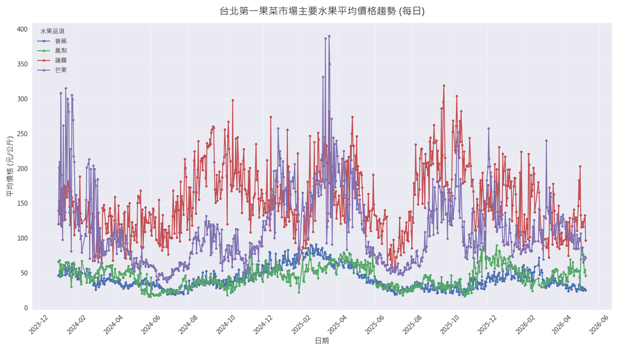

### 水果交易量時間序列圖

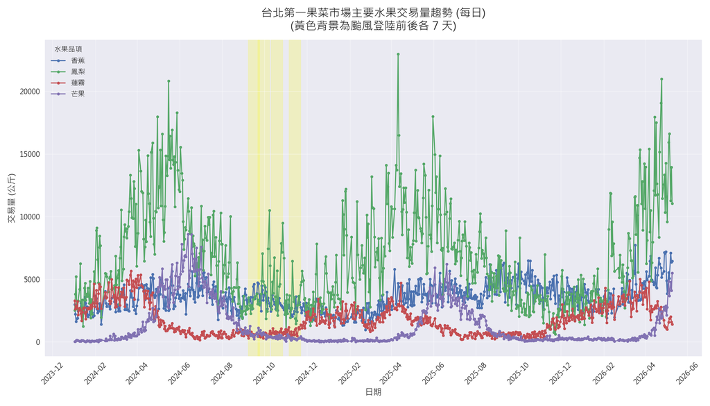

黃色背景表示颱風登陸前後各 7 天的時間區間。

### 颱風前後價格比較圖

[figure not shown]

左圖：黃色背景表示颱風期間；右圖：對比四次颱風事件期間的平均價格。

## 九、初步分析方向

本研究以描述統計與時間序列圖觀察水果價格的長期波動。首先從整體價格與交易量時序圖中可觀察到四種水果在 2024 年以來的季節性波動，某些月份特定水果呈現價格高峰與交易量變化。

本專題以謹慎方式解讀資料，未直接宣稱因果關係，而是將颱風與價格波動之間的關聯定位為探索性與關聯性分析。

## 十、結論與後續工作

最終繳交時，至少應包含 `INSTRUCTIONS.md` 或 `CLAUDE.md`、`LOG.md` 與 `REPORT.html`，並確認 `REPORT.html` 中的資料量與圖表說明已根據實際執行結果補齊。